# Are Neighborhoods with Public Housing Projects Brighter?(Phoenix AZ)

Naoya Morishita

# Introduction

## Introduction

This exercise will look at brightness values across the city of Phoenix Arizona, and compare the values between grids with and without public housings, referring to [this case study](https://github.com/agroimpacts/USFlite/blob/main/external/notebooks/nightlights-part2.md).

## Datasets

- The Monthly Average [night lights between 2012-2023 from NASA](https://www.earthdata.nasa.gov/learn/backgrounders/nighttime-lights)
- SAVI from the [Landsat8](https://www.usgs.gov/landsat-missions/landsat-8)
- Gridded Population from [the US Census in 2020](https://www.census.gov/topics/population.html)
- Gridded Public Housing Density Estimated from [HUD Data](https://www.huduser.gov/portal/datasets/assthsg.html#2009-2022_data) & [Microsoft Building Footprint Data](https://github.com/microsoft/USBuildingFootprints)
- Gridded Building Density Data from [USGS](https://www.sciencebase.gov/catalog/item/5d27a8dfe4b0941bde650fc7)

## Showing Data

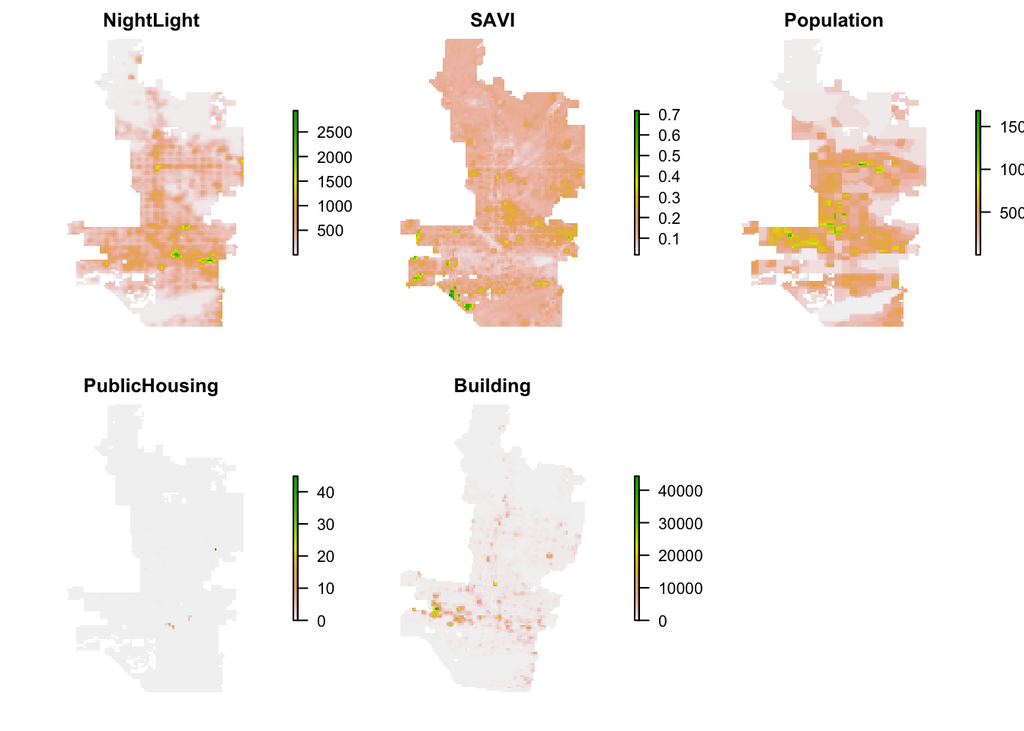

```r
plot_noaxes(b)
```

# Analysis

## Showing Relations: With Regression

Now, we are going to plot the relations between the nighttime light radiance and the other variables with `ggplot2`. Note that the values are all scaled. Here are some of major findings:

- Medium positive correlation between nightlight and population/ public housing (filtered)
- Small positive and negative correlation between nightlight and building volume/ SAVI, respectively
- Random correlations between nightlight and public housing

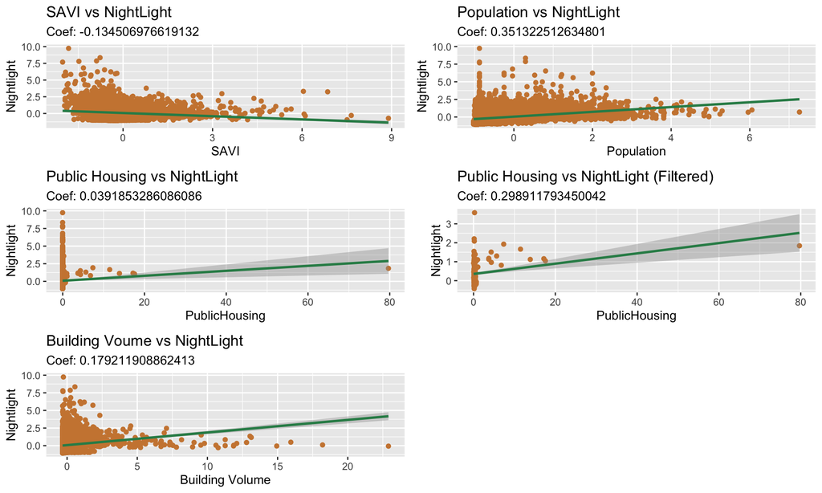

```r
# Converting into Spatial DataFrame after Rescaling the Values====
p_scaled <- b %>%
  raster::scale(.) %>%
  rasterToPolygons(.) %>%
  st_as_sf %>%
  na.omit(.) %>%
  mutate(PhLevel = ifelse(PublicHousing > -0.02972701, "Y", "N"))

# Creating Plots====
# Creating a plot of savi----
g1 <- p_scaled %>% # creating a plot and save it as a variable
  ggplot(aes(x = SAVI, y = NightLight))+ # placing savi on x and nightlight on y
  geom_jitter(color = "peru")+
  geom_smooth(color = "seagreen",
              method = "lm")+ # using linear regression
  ggtitle("SAVI vs NightLight", # placing a main title
          subtitle = paste0("Coef: ", # placing a subtitle with str concatnation with coef
                            cor(p_scaled$ NightLight, # calculating correration coef of nightlight and
                                p_scaled$ SAVI)))+ # savi
  xlab("SAVI")+ # placing x label
  ylab("Nightlight") # placing ylabel
# g1

# Creating a plot of population----
g2 <- p_scaled %>%
  ggplot(aes(x = Population, y = NightLight))+
  geom_jitter(color = "peru")+
  geom_smooth(color = "seagreen",
              method = "lm")+
  ggtitle("Population vs NightLight",
          subtitle = paste0("Coef: ",
                            cor(p_scaled$ NightLight,
                                p_scaled$ Population)))+
  xlab("Population")+
  ylab("Nightlight")
# g2

# Creating a plot of public housing (all)----
g3 <- p_scaled %>%
  ggplot(aes(x = PublicHousing, y = NightLight))+
  geom_jitter(color = "peru")+
  geom_smooth(color = "seagreen",
              method = "lm")+
  ggtitle("Public Housing vs NightLight",
          subtitle = paste0("Coef: ",
                            cor(p_scaled$ NightLight,
                                p_scaled$ PublicHousing)))+
  xlab("PublicHousing")+
  ylab("Nightlight")
# g3

# Creating a plot of public housings (filtered)----
p_filtered <- p_scaled %>% # creating a new table
  filter(PhLevel == "Y") # containing only those with ph

g3_2 <- p_filtered %>%
  ggplot(aes(x = PublicHousing, y = NightLight))+
  geom_jitter(color = "peru")+
  geom_smooth(color = "seagreen",
              method = "lm")+
  ggtitle("Public Housing vs NightLight (Filtered)",
          subtitle = paste0("Coef: ",
                            cor(p_filtered$ NightLight,
                                p_filtered$ PublicHousing)))+
  xlab("PublicHousing")+
  ylab("Nightlight")
# g3_2

# Creating a plot of total building volumes----
g4 <- p_scaled %>%
  ggplot(aes(x = Building, y = NightLight))+
  geom_jitter(color = "peru")+
  geom_smooth(color = "seagreen",
              method = "lm")+
  ggtitle("Building Voume vs NightLight",
          subtitle = paste0("Coef: ",
                            cor(p_scaled$ NightLight,
                                p_scaled$ Building)))+
  xlab("Building Volume")+
  ylab("Nightlight")
# g4

# Creating a heatmap of correlation coef----
# library(GGally)
# g5 <- ggcorr(p_scaled[, 1:5] %>% # using only first 5 columns
#                st_drop_geometry(), # converting sf into df # for avoiding error
#              method = c("everything", "pearson"),
#              legend.size = 1)
# # g5

# Showing the Graphs in CowPlots====
cowplot::plot_grid(g1, g2, g3, g3_2, g4, # g5, # adding 5 plots
                   nrow = 3, # with 3 rows
                   align = "vh", # vertically & horizontally alligned
                   axis = "l") # aligned to left
```

## Comparing Radiances: Boxplots

The following codes compare median radiance from similar population and building density in between grids with/ without public housing to answer the question of “Are Neighborhoods with Public Housing Projects Brighter?” The steps are:

1. Calculate 1/3 and 2/3 percentiles of population and building density separately to assign levels
2. Divide the data frame into grids with ph and without.
3. Assign the levels to each grid to classify 9 levels (Population: low & Density: low, Population: Middle & Density: Low etc…)
4. Compare medians from all classes between those with and without public housings.

The result seems to be: - There is no record of grids with public housings for level 1 and 4 - However, the radiance from grids with public housing is higher in 4 out of the other 7 levels.

```r
# Preparing for Analysis====
# Calculating 33% quantiles----
pop_q <- p_scaled %>%
  pull(Population) %>% # using pop column
  quantile(., probs = seq(0, 1, 1/3)) # setting probabilities for making every 0.2 threshold

bld_q <- p_scaled %>%
  pull(Building) %>%
  quantile(., probs = seq(0, 1, 1/3))

# Defining which class the records belong to----
popvol <- p_scaled %>%
  mutate(., pop_class = cut(Population, pop_q, include.lowest = T, dig.lab = 4)) %>%
  mutate(., bld_class = cut(Building, bld_q, include.lowest = T, dig.lab = 2))

# Counting the numbers of each class with crosstaburation----
tab_original <- table(pop = popvol$ pop_class,
             bvol = popvol$ bld_class) %>%
  as.data.frame(.)

# Creating a from to table----
tab <- tab_original %>%
separate(., col = pop, into = c("pop_l", "pop_u"), sep = ",") %>%
  separate(., col = bvol, into = c("bvol_l", "bvol_u"), sep = ",") %>%
  mutate(., pop_l = as.numeric(gsub("\\(|\\[", "", pop_l))) %>%
  mutate(., pop_u = as.numeric(gsub("\\]", "", pop_u))) %>%
  mutate(., bvol_l = as.numeric(gsub("\\(|\\[", "", bvol_l))) %>%
  mutate(., bvol_u = as.numeric(gsub("\\]", "", bvol_u))) %>%
  filter(., Freq > 1)

# Dividing into Grids with Ph and without====
no_ph_df <- lapply(1: nrow(tab),
                function(x){
                  l <- tab[x, ]
                  # print(l)
                  p_scaled %>%
                    filter(PhLevel == "N") %>%
                    filter(between(Population,
                                   l$ pop_l,
                                   l$ pop_u)) %>%
                    filter(between(Building,
                                   l$ bvol_l,
                                   l$ bvol_u)) %>%
                    mutate(level = factor(x))
                }) %>%
  bind_rows()
print(no_ph_df[1:5,])
```

```
## Simple feature collection with 5 features and 7 fields
## Geometry type: POLYGON
## Dimension:     XY
## Bounding box:  xmin: -112.1667 ymin: 33.90846 xmax: -112.1542 ymax: 33.91679
## Projected CRS: NAD83 / Arizona Central
##   NightLight       SAVI Population PublicHousing   Building PhLevel level
## 1  -1.040808 -0.3990817 -0.9990789   -0.02972701 -0.3188026       N     1
## 2  -1.040660 -0.3079023 -0.9990789   -0.02972701 -0.3188026       N     1
## 3  -1.037191 -0.1716202 -0.9990790   -0.02972701 -0.3188026       N     1
## 4  -1.040067 -0.3029720 -0.9990777   -0.02972701 -0.3188026       N     1
## 5  -1.039771 -0.1899341 -0.9990777   -0.02972701 -0.3188026       N     1
##                         geometry
## 1 POLYGON ((-112.1667 33.9167...
## 2 POLYGON ((-112.1625 33.9167...
## 3 POLYGON ((-112.1583 33.9167...
## 4 POLYGON ((-112.1667 33.9126...
## 5 POLYGON ((-112.1625 33.9126...
```

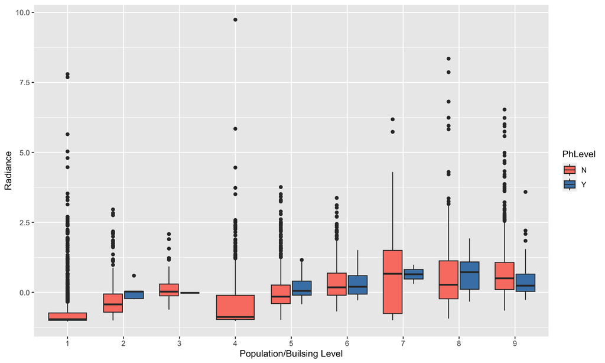

```r
# Creagting ph df----
ph_df <- lapply(1: nrow(tab),
                function(x){
                  l <- tab[x, ]
                  # print(l)
                  p_scaled %>%
                    filter(PhLevel == "Y") %>%
                    filter(between(Population,
                                   l$ pop_l,
                                   l$ pop_u)) %>%
                    filter(between(Building,
                                   l$ bvol_l,
                                   l$ bvol_u)) %>%
                    mutate(level = factor(x))
                }) %>%
  bind_rows()

# Combining the dfs----
all_df <- bind_rows(no_ph_df, ph_df)

# Creating Box Plots====
all_df %>%
  ggplot() + geom_boxplot(aes(x = level,
                              y = NightLight,
                              fill = PhLevel)) +
  xlab("Population/Builsing Level") +
  ylab("Radiance") +
  scale_fill_manual(values = c("salmon", "steelblue"))
```

### Comparing Radiances: Data Frame

```r
all_df %>%
  st_drop_geometry() %>% # converting sf to df
  group_by(PhLevel, level) %>% # grouping by ph level and population quantile
  summarize(MedianRadiance = median(NightLight)) %>% # calculating medians
  pivot_wider(names_from = PhLevel, values_from = MedianRadiance) %>% # adding columns for comparison
  mutate(Difference = Y - N) %>% # adding a column
  rename(PopulationBuildingLevel = level) # renaming a column
```

```
## # A tibble: 9 × 4
##   PopulationBuildingLevel       N       Y Difference
##   <fct>                     <dbl>   <dbl>      <dbl>
## 1 1                       -0.963  NA         NA
## 2 2                       -0.432   0.0264     0.458
## 3 3                        0.0241 -0.0194    -0.0435
## 4 4                       -0.880  NA         NA
## 5 5                       -0.154   0.0511     0.205
## 6 6                        0.177   0.199      0.0217
## 7 7                        0.663   0.645     -0.0173
## 8 8                        0.271   0.721      0.450
## 9 9                        0.500   0.238     -0.263
```

## Are those with Ph less or more vegetated?

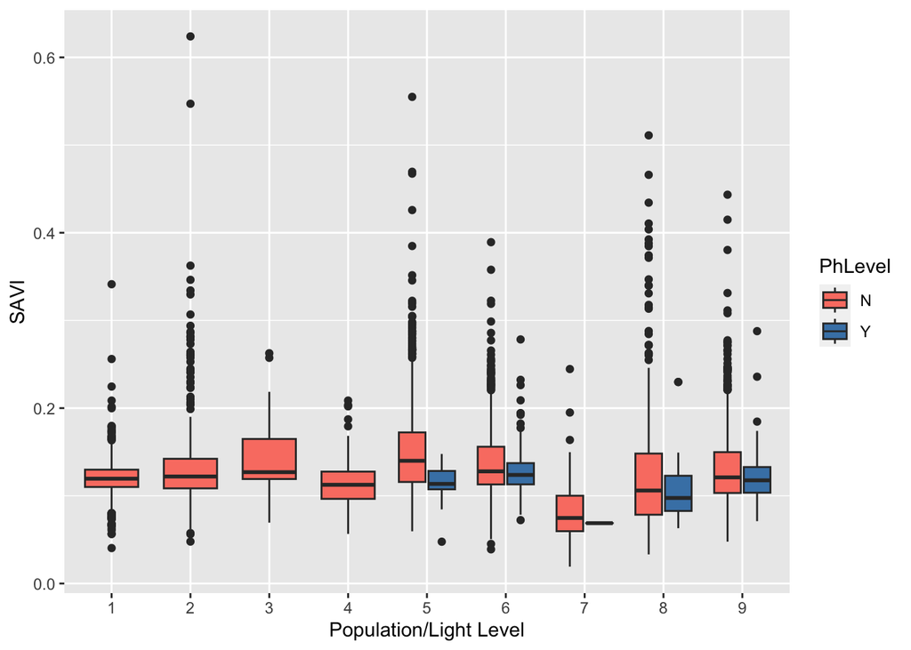

```r
# Preparing for the Analysis====
# Creating savi column without scaling----
savi_p <- b[[2]] %>%
  rasterToPolygons() %>%
  st_as_sf() %>%
  na.omit() %>%
  rename(savi_original = SAVI)

all_df <- st_join(
          all_df,
          savi_p,
          join = st_equals,
          left = F)

# Creating light classes----
lt_q <- all_df %>%
  pull(NightLight) %>% # using pop column
  quantile(., probs = seq(0, 1, 1/3)) # setting probabilities for making every 0.2 threshold

# Defining which class the records belong to----
ltpop <- all_df %>%
  mutate(., lt_class = cut(NightLight, lt_q, include.lowest = T, dig.lab = 4)) %>%
  mutate(., pop_class = cut(Population, pop_q, include.lowest = T, dig.lab = 2))

# Counting the numbers of each class with crosstaburation----
tab_original <- table(pop = ltpop$ pop_class,
             lt = ltpop$ lt_class) %>%
  as.data.frame(.)

# Creating a "from to" table----
tab <- tab_original %>%
separate(., col = pop, into = c("pop_l", "pop_u"), sep = ",") %>%
  separate(., col = lt, into = c("lt_l", "lt_u"), sep = ",") %>%
  mutate(., pop_l = as.numeric(gsub("\\(|\\[", "", pop_l))) %>%
  mutate(., pop_u = as.numeric(gsub("\\]", "", pop_u))) %>%
  mutate(., lt_l = as.numeric(gsub("\\(|\\[", "", lt_l))) %>%
  mutate(., lt_u = as.numeric(gsub("\\]", "", lt_u))) %>%
  filter(., Freq > 1)

# Dividing into Grids with Ph and without====
no_ph_df <- lapply(1: nrow(tab),
                function(x){
                  l <- tab[x, ]
                  all_df %>%
                    filter(PhLevel == "N") %>%
                    filter(between(Population,
                                   l$ pop_l,
                                   l$ pop_u)) %>%
                    filter(between(NightLight,
                                   l$ lt_l,
                                   l$ lt_u)) %>%
                    mutate(level = factor(x))
                }) %>%
  bind_rows()

# Creagting ph df----
ph_df <- lapply(1: nrow(tab),
                function(x){
                  l <- tab[x, ]
                  all_df %>%
                    filter(PhLevel == "Y") %>%
                    filter(between(Population,
                                   l$ pop_l,
                                   l$ pop_u)) %>%
                    filter(between(NightLight,
                                   l$ lt_l,
                                   l$ lt_u)) %>%
                    mutate(level = factor(x))
                }) %>%
  bind_rows()

# Combining the dfs----
all_df <- bind_rows(ph_df, no_ph_df)

# Creating a Box Plots====
all_df %>%
  ggplot() + geom_boxplot(aes(x = level,
                              y = savi_original,
                              fill = PhLevel)) +
  xlab("Population/Light Level") +
  ylab("SAVI") +
  scale_fill_manual(values = c("salmon", "steelblue"))
```

```r
all_df %>%
  st_drop_geometry() %>% # converting sf to df
  group_by(PhLevel, level) %>% # grouping by ph level and population quantile
  summarize(MedianSAVI = median(savi_original)) %>% # calculating medians
  pivot_wider(names_from = PhLevel, values_from = MedianSAVI) %>% # adding columns for comparison
  mutate(Difference = Y - N) %>% # adding a column
  rename(PopulationBuildingLevel = level) %>%  # renaming a column
  print()
```

```
## # A tibble: 9 × 4
##   PopulationBuildingLevel      N       Y Difference
##   <fct>                    <dbl>   <dbl>      <dbl>
## 1 1                       0.120  NA        NA
## 2 2                       0.122  NA        NA
## 3 3                       0.127  NA        NA
## 4 4                       0.113  NA        NA
## 5 5                       0.140   0.114    -0.0264
## 6 6                       0.128   0.124    -0.00406
## 7 7                       0.0747  0.0688   -0.00590
## 8 8                       0.106   0.0975   -0.00851
## 9 9                       0.121   0.118    -0.00337
```